# Introduction to Open Data Science

Gyan Dookie

8 March 2017

## **Final assignment - Gyan Dookie**

```r
# knitr::opts_chunk$set(echo = TRUE)


#install.packages("dplyr",  repos = "https://ftp.acc.umu.se/mirror/CRAN/")
#install.packages("corrplot")

#install.packages("tidyr")
library(tidyr)
library(dplyr)
library(corrplot)
library(tidyr)

library(ggplot2)
library(GGally)


setwd("/Users/gyandookie/IODS-final")


refBomb<- read.csv ("data/refBomb.csv", header=TRUE, sep=",", stringsAsFactors = FALSE)
```

# Final Assignment

### Overview

##### We live in a turbulent world today. One current socially destabilizing and publically debated phenomena has been the flow of refugees and asylum seekers from Middle East to Europe. In this IODS final assignment my aim is to explore the possible relations among variables that are in my view connected to the ongoing so called “refugee crisis”. I’ll be focusing on countries that are bombing the countries where the major flow of refugees originate from. Here are some questions that interest me. How many refugees do the “bombing” countries have / accept inside their borders? Does taking part in foreign wars increase the risk of terror attacks? How are these warring countries connected to the arms trade? How succesful economically and socially are these countries? My hypothesis is at this point still vague. It could be put bluntly though: “Rich countries that are main players in the arms business are bombing poor countries and by doing so are increasing refugee flows across their borders and the risk of terrorist attacks.” Nevertheless, this would be likely oversimplifying the reality.

In the following data analysis I’m going to perform Principal Component Analysis (PCA) on the ref dataset. Before the actual analysis I’ll go through some preliminary explorations of the data.

#### Data wrangling

##### Variables

It’s a good idea to introduce the variables of the ref dataset before moving further.

- Country
- FSI - Fragile States Index, a variable combined of other variables estimating e.g. stability, human rights, freedom of press in a country
  - This data is from Fund for Peace’s yearly published Fragile States -dataset
- TerAtt = How many islamist terror attacks has there been in the country between 2015-2017
- CtryBomb = Hown many countries the country has been bombing between 2015-2016
- ArmSale = The amount of a country’s arms exports (2015)
  - This data is from SIPRI’s MILEX dataset
- RefOrig = The amount of refugees originating from a country
- GNI = Gross National Income per Capita
  - Gross National Income data was provided by World Bank
- refPer - The amount of refugees in the asylum country
  - This variable was produced/mutated by me (by multiplying the amount of refugees / asylum seekers in a country of asylum by hundred and then dividing it with the population of that country)

##### Methods

The data was selected from multiple sources as can seen above. My aim was to bring together data related to the broader so called refugee crisis -phenoma, but that hasn’t necessary been so often brought together. I ventured to also add some variables that in my view are actants in this larger phenomena. I had to perform many different data wrangling operations to combine all the data into one dataset in a refined form. Here are some of the methods I used: importing, selecting, mutating, deleting or completing data rows with blank (e.g. NA) values, changing the datatype of variables, combining data.

Here is the link to my data wrangling file.

- [The datawrangling file](https://github.com/gdookie/IODS-final/blob/master/data/create_ref.R)

### Brief description of the used methods

My method is to bring together different variables that seem to revolve around a phenomena and see what kind of correlations this operation reveals. After some basic explorations (i.e. the structure and summaries of the data) I’ll produce the correlations of the data and plot these visually. In the next phase I’ll use the Principal component analysis (PCA) and interpret what this reveals. Finally I’ll add some more visualizations of the data.

### 1. Preliminary explorations of the data

#### **1.1 The structure and the dimensions of the data**

```r
refBombC <- refBomb
refBomb<- refBomb[-1]
dim(refBomb)
```

```
## [1] 139   8
```

```r
str(refBomb)
```

```
## 'data.frame':    139 obs. of  8 variables:
##  $ Country : chr  "South Sudan" "Sudan" "Chad" "Afghanistan" ...
##  $ FSI     : int  1138 1115 1101 1079 1051 1047 1038 1035 1017 1007 ...
##  $ TerAtt  : int  0 0 0 0 0 21 0 21 10 0 ...
##  $ CtryBomb: int  0 0 0 0 0 1 0 0 0 0 ...
##  $ ArmSale : int  0 0 0 0 0 0 0 0 1 0 ...
##  $ RefOrig : int  616 659 15 2596270 37 370 15 55 316 72 ...
##  $ GNI     : int  1810 3820 2080 1960 1740 15190 1140 5740 5110 770 ...
##  $ refPer  : num  2.13 0.77 2.63 0.79 0 0.76 0.07 0 0.83 0.48 ...
```

#### **1.2 The summary of the data**

Here we’ll print out the summary of the data with the *summary()* function to get a grasp of the min, max, median, mean and quantiles of the data.

```r
summary(refBomb)
```

```
##    Country               FSI             TerAtt          CtryBomb
##  Length:139         Min.   : 188.0   Min.   : 0.000   Min.   :0.0000
##  Class :character   1st Qu.: 487.0   1st Qu.: 0.000   1st Qu.:0.0000
##  Mode  :character   Median : 722.0   Median : 0.000   Median :0.0000
##                     Mean   : 677.5   Mean   : 0.554   Mean   :0.1511
##                     3rd Qu.: 855.5   3rd Qu.: 0.000   3rd Qu.:0.0000
##                     Max.   :1138.0   Max.   :21.000   Max.   :7.0000
##     ArmSale          RefOrig             GNI             refPer
##  Min.   :   0.0   Min.   :      1   Min.   :   710   Min.   : 0.0000
##  1st Qu.:   0.0   1st Qu.:     10   1st Qu.:  3870   1st Qu.: 0.0000
##  Median :   0.0   Median :     58   Median : 11650   Median : 0.0400
##  Mean   : 142.7   Mean   :  46684   Mean   : 18638   Mean   : 0.3642
##  3rd Qu.:   0.0   3rd Qu.:    272   3rd Qu.: 25645   3rd Qu.: 0.2900
##  Max.   :9894.0   Max.   :3869626   Max.   :132900   Max.   :13.0000
```

Here are the standard deviations of the variables.

```r
# Lasketaan muuttujien keskihajonnat (tehdään tämä uudestaan, kun muuttujat on skaalattu)
summarise (refBomb, sd(FSI),sd(TerAtt),sd(CtryBomb),sd(ArmSale),sd(RefOrig),sd(GNI),sd(refPer))
```

```
##    sd(FSI) sd(TerAtt) sd(CtryBomb) sd(ArmSale) sd(RefOrig) sd(GNI)
## 1 247.9725   2.787583    0.7113334     885.208    393900.1 20270.7
##   sd(refPer)
## 1   1.200327
```

#### **1.3 The graphical overview of the summarized data**

Let’s visualize our data to get a better overall picture of it. First we’ll produce a matrix plot with the basic package’s pairs() and then with GGally package’s ggpairs().

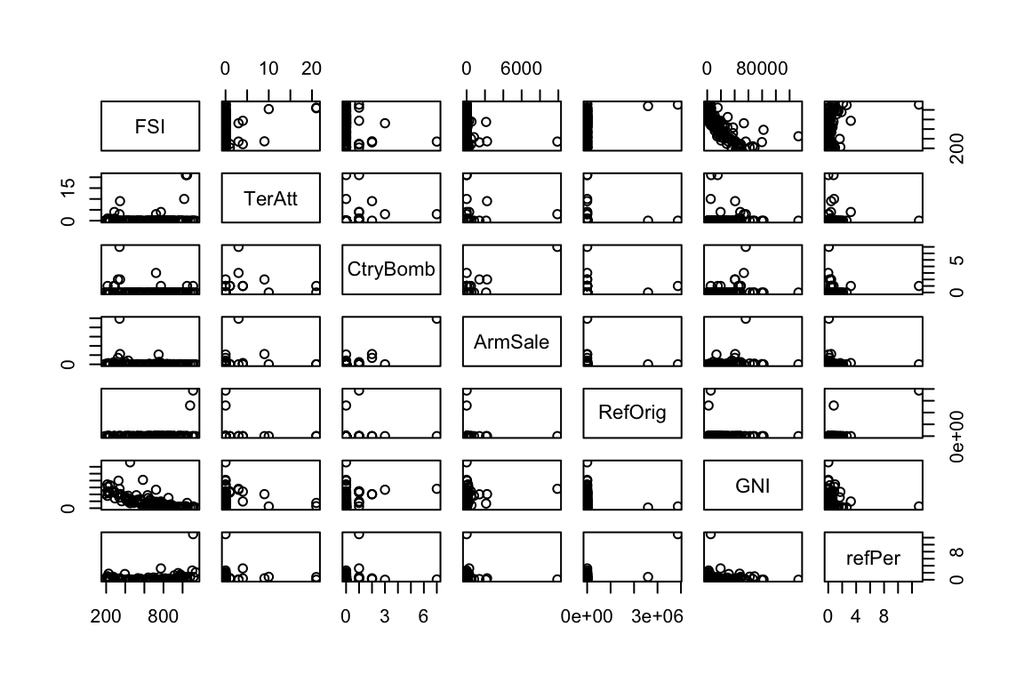

```r
# Then we'll take a look at the graphical overview
refBomb_1 <- select(refBomb, -Country)
pairs(refBomb_1)
```

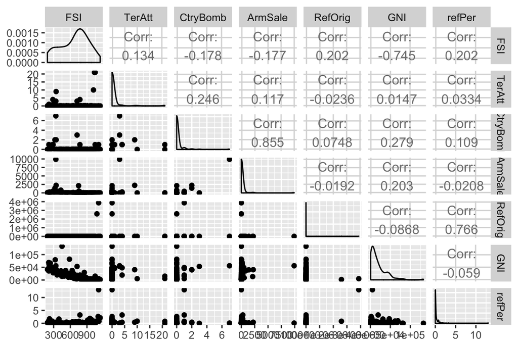

```r
ggpairs(refBomb_1)
```

#### **1.4 The correlations of the data with corrplot()**

Now it’s time to produce a table of the correlations with the *cor()* function. Here the correlations were rounded to two desimals to save space.

```r
cor_matrix<-cor(refBomb_1)%>% round(2)
cor_matrix
```

```
##            FSI TerAtt CtryBomb ArmSale RefOrig   GNI refPer
## FSI       1.00   0.13    -0.18   -0.18    0.20 -0.74   0.20
## TerAtt    0.13   1.00     0.25    0.12   -0.02  0.01   0.03
## CtryBomb -0.18   0.25     1.00    0.85    0.07  0.28   0.11
## ArmSale  -0.18   0.12     0.85    1.00   -0.02  0.20  -0.02
## RefOrig   0.20  -0.02     0.07   -0.02    1.00 -0.09   0.77
## GNI      -0.74   0.01     0.28    0.20   -0.09  1.00  -0.06
## refPer    0.20   0.03     0.11   -0.02    0.77 -0.06   1.00
```

#### **1.5 The graphical overview of correlations with the advanced corrplot() function**

Here’s the visualization of the correlation matrix with the advanced *corrplot()* function. To reduce repetition, we’ll visualize only the upper part of the plot (as is well known, the top part of the correlation matrix contains the same correlations as the bottom part)

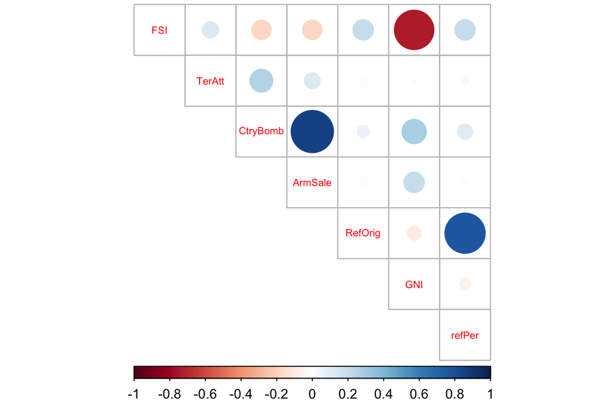

```r
# Now we'll visualize the correlation matrix. To reduce repetition, we'll visualize only the upper part of the plot (as is well known, the top part of the correlation matrix contains the same correlations as the bottom part)
corrplot(cor_matrix, method="circle", type="upper", cl.pos="b", tl.pos = "d", tl.cex=0.6)
```

#### **1.6 The above summaries and visualizations showed the following**

**Here are some of the exposed correlations**

**The distributions of the data**

```r
#
# boxplots
```

[output not shown]

#### **2.2 PCA on standardized/scaled data**

```r
# standardize the variables
refBomb_std <- scale(refBomb_1)
summary(refBomb_std)
```

```
##       FSI              TerAtt           CtryBomb          ArmSale
##  Min.   :-1.9742   Min.   :-0.1987   Min.   :-0.2124   Min.   :-0.1612
##  1st Qu.:-0.7684   1st Qu.:-0.1987   1st Qu.:-0.2124   1st Qu.:-0.1612
##  Median : 0.1793   Median :-0.1987   Median :-0.2124   Median :-0.1612
##  Mean   : 0.0000   Mean   : 0.0000   Mean   : 0.0000   Mean   : 0.0000
##  3rd Qu.: 0.7177   3rd Qu.:-0.1987   3rd Qu.:-0.2124   3rd Qu.:-0.1612
##  Max.   : 1.8569   Max.   : 7.3347   Max.   : 9.6283   Max.   :11.0158
##     RefOrig             GNI              refPer
##  Min.   :-0.1185   Min.   :-0.8844   Min.   :-0.30340
##  1st Qu.:-0.1185   1st Qu.:-0.7286   1st Qu.:-0.30340
##  Median :-0.1184   Median :-0.3448   Median :-0.27007
##  Mean   : 0.0000   Mean   : 0.0000   Mean   : 0.00000
##  3rd Qu.:-0.1178   3rd Qu.: 0.3457   3rd Qu.:-0.06179
##  Max.   : 9.7054   Max.   : 5.6368   Max.   :10.52699
```

```r
#str(human_std)
```

```r
# perform principal component analysis (with the SVD method)
pca_refBomb <- prcomp(refBomb_std)
s <- summary(pca_refBomb)
pca_pr <- round(100*s$importance[2, ], digits = 1)
pca_pr
```

```
##  PC1  PC2  PC3  PC4  PC5  PC6  PC7
## 32.4 27.2 19.2 12.8  3.5  3.2  1.7
```

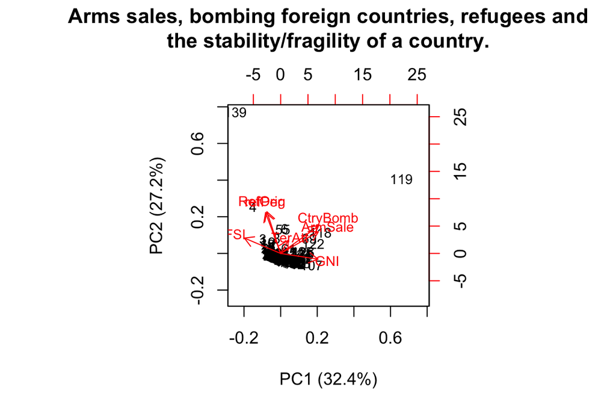

```r
pc_lab <- paste0(names(pca_pr), " (", pca_pr, "%)")

# draw a biplot of the principal component representation and the original variables
## remember to add caption names (in place of variable names) to the plots describing the phenomenons


#biplot(pca_human, choices = 1:3, cex=c(1 ,1.2), col= c("grey40", "deeppink2"))

biplot(pca_refBomb, choices = 1:2, cex = c(0.8, 0.8), col = c("black", "red"), xlab = pc_lab[1] , ylab = pc_lab[2], main="\n Arms sales, bombing foreign countries, refugees and \n the stability/fragility of a country. \n\n\n")
```

**Let’s take a closer look at the countries on the “west side” of the biplot and close to PC2.**

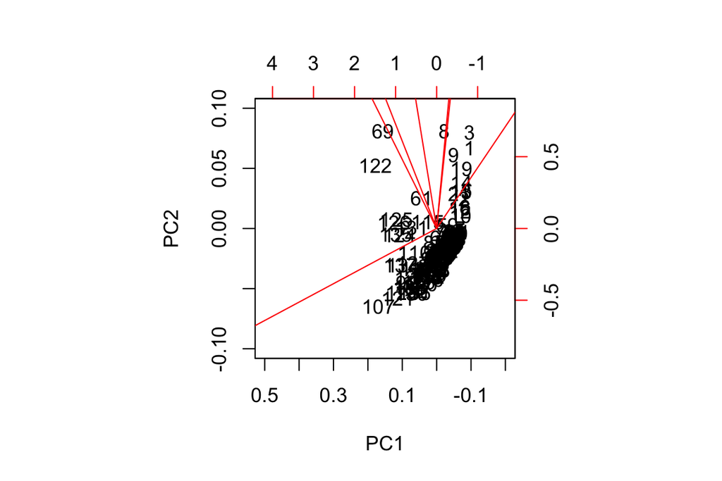

```r
biplot(pca_refBomb, expand=4, xlim=c(0.5, -0.2), ylim=c(-0.1, 0.1))
```

#### **2.3 Intepretation and analysis of PCA and the corresponding biplots**

The PCA biplot based on the standardized variables offers visual information that supports our earlier findings.

**Intepretation of PC1**

Generally speaking, the 1st principal component captures the maximum amount of variance from the features in the original data. Here the amount of variance of the data captured by PC1 is 32.4 %. The variables/features connected to the PC1 dimension are CtryBomb, ArmSale and TerAtt which point their arrows in a close cluster and in a slight angle horizontally to the right. So from this we can deduce that these variables have some correlation among each other. FSI and GNI are pointing to oppisite directions and thus are negatively correlated. The FSI-GNI -arrowline is in a slight angle. It is more aligned with the PC1 thatn PC2.

**Intepretation of PC2**

The 2nd principal component PC2 is orthogonal to the first and it captures the maximum amount of variability/variance left. Here that amount is 27.2 % and variables in the closest relationship to this principal component are RefOrig and perP. So the stability of a country is connected to the amount of refugees in that country.

#### **2.4 Further plotting and analysis of the correlations (and their variables) that the above plotting and analysis revealed as interesting**

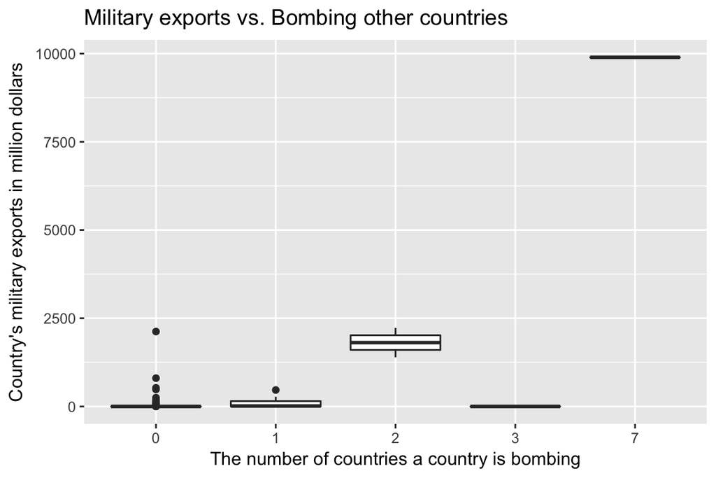

Looks like the above boxplot confirms our previous findings. The amount of a country’s military exports seem to increase the chance of that country bombing other countries. Nevertheless, we should test for other possible variables that could increase the likelihood of this before making any definitive assumptions.